# writeup03

Wenqi Lyu

9/20/2020

In this blog, we would like to discuss the probability that the Brave win the world series game.

# 1 Introduction

In the beginning, we have these setup:

1. Suppose that the Braves and the Yankees are teams competing in the World Series.
2. Suppose that in any given game, the probability that the Braves win is *P*<sub>*B*</sub> and the probability that the Yankees win is *P*<sub>*Y*</sub> = 1 − *P*<sub>*B*</sub>.
3. The world series is a best-of-7 match-up between the champions of the American and National Leagues of Major League Baseball.

```r
library(ggplot2)
```

Now, we have following questions that need to address, so that we could understand the probability of winning world series better.

# 2 Questions

## 2.1 What is the probability that the Braves win the World Series given that *P*<sub>*B*</sub> = 0.55?

```r
win <- pnbinom(3,4,.55)
```

The probability that the Braves win the World Series given that *P*<sub>*B*</sub> = 0.55 is 0.6082878

## 2.2 What is the probability that the Braves win the World Series given that *P*<sub>*B*</sub> = *x*? This will be a figure (see below) with *P*<sub>*B*</sub> on the x-axis and *P*(Braves win World Series) on the y-axis.

We want to find out the relationship between the probability that the Brave win the head-to-head matchup and the probability that Brave win the world series. Therefore, we make a plot.

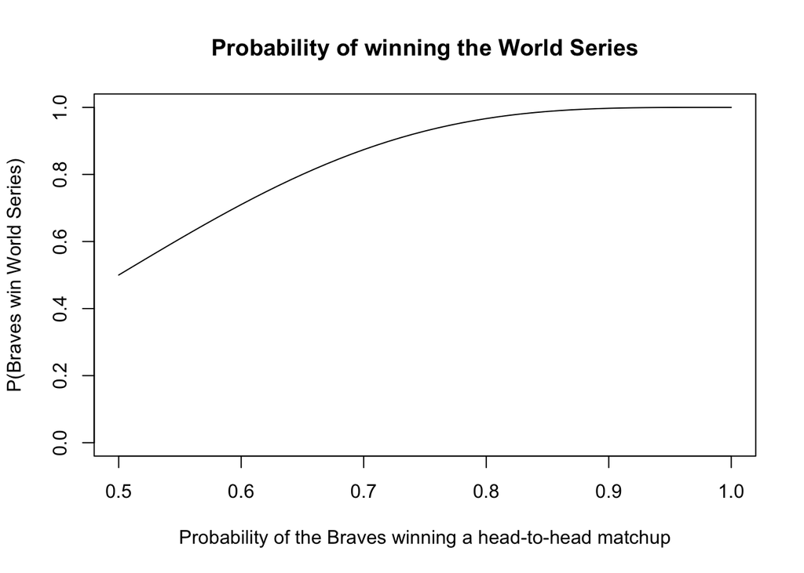

```r
pb <- seq(0.5,1,by = 0.01)
brave_win <- pnbinom(3,4,pb)

plot(x=pb,
     y=brave_win,
     type="l",
     xlim = c(0.5,1),
     ylim = c(0:1),
     xlab = "Probability of the Braves winning a head-to-head matchup",
     ylab = "P(Braves win World Series)",
     main = "Probability of winning the World Series")
```

- In this plot, When the probability of braves winning a head-to-head matchup increases, the probability of Braves win world series increase.

## 2.3 Suppose one could change the World Series to be best-of-9 or some other best-of-X series. What is the shortest series length so that *P*(Braves win World Series|*P*<sub>*B*</sub> = .55) ≥ 0.8

```r
x <- seq(1,99,2)
prob_win <- pnbinom((x-1)/2,(x+1)/2,0.55)
x[(which(prob_win>0.8))[1]]
```

```
## [1] 71
```

- 71 is the shortest series length so that *P*(Braves win World Series|*P*<sub>*B*</sub> = .55) ≥ 0.8

## 2.4 What is the shortest series length so that *P*(Braves win World Series|*P*<sub>*B*</sub> = *x*) ≥ 0.8? This will be a figure (see below) with *P*<sub>*B*</sub> on the x-axis and series length is the y-axis.

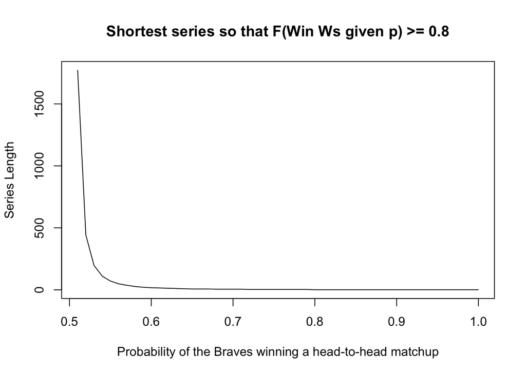

```r
pb = seq(0.51,1,by=0.01)
short.len = NA
for (i in 1:length(pb)) {
  num.win = seq(1,1000,by=1)
  num.loss = num.win -1
  pws = pnbinom(num.loss,num.win,pb[i])
  len.ser=num.loss+num.win
  short.len[i] = len.ser[which(pws >= 0.8)[1]]
}

plot(
  x=pb,
  y=short.len,
  type="l",
  xlab = "Probability of the Braves winning a head-to-head matchup",
  ylab = "Series Length",
  main = "Shortest series so that F(Win Ws given p) >= 0.8"
)
```

- In this plot, we could know that the series length are almost 0, when the probaility of the Braves winning a head-to-head matchup is close to 1.

## 2.5 Calculate *P*(*P*<sub>*B*</sub> = 0.55|Braves win World Series in 7 games) under the assumption that either *P*<sub>*B*</sub> = 0.55 or *P*<sub>*B*</sub> = 0.45. Explain your solution.

From the concept of the conditional probability, we could know:

*P*(*P*<sub>*B*</sub> = 0.55|Braves win World Series in 7 games) = *P*(*P*<sub>*B*</sub> = 0.55,Braves win World Series in 7) / *P*(Braves win World Series in 7 games) = *P*(Braves win World Series in 7 games| *P*<sub>*B*</sub> = 0.55) * *P*<sub>*B*</sub> = 0.55 / *P*(Braves win World Series in 7 games)

In order to know*P*(*P*<sub>*B*</sub> = 0.55|Braves win World Series in 7 games), we need to find out *P*(Braves win World Series in 7 games| *P*<sub>*B*</sub> = 0.55) ; *P*(Braves win World Series in 7 games) ; *P*<sub>*B*</sub> = 0.55

1.*P*(Braves win World Series in 7 games| *P*<sub>*B*</sub> = 0.55)

```r
dnbinom(3,4,.55)
```

```
## [1] 0.1667701
```

2.*P*(Braves win World Series in 7 games)

```r
(dnbinom(3,4,0.45)+dnbinom(3,4,0.55))/2
```

```
## [1] 0.1516092
```

3.*P*<sub>*B*</sub> = 0.55

```r
0.5
```

```
## [1] 0.5
```

calculate: *P*(*P*<sub>*B*</sub> = 0.55|Braves win World Series in 7 games)

```r
dnbinom(3,4,.55)/((dnbinom(3,4,0.45)+dnbinom(3,4,0.55))/2)*0.5
```

```
## [1] 0.55
```